# crude_variants_stats

started: Alexey Larionov, 27Feb2017  
last updated: Alexey Larionov, 19Sep2019

# Summary

Calculate for each variant:

- Fisher tests for NFE vs BC
- Fisher test for UBC vs CBC
- prop.trend.test for NFE:UBC:CBC (along to 1:2:3 scores)

### Explore crude aggregated stats per variant

Mean agregated MAC: 2.2  
Median agregated MAC: 1

The deflation in QQ-plots reflects low AC-s (becuase of selected low AF-s)

### Input and output data:

- 162 variants x 664 samples (467BC = 232UBC + 235CBC and 197NFE)

### Overall:

No significantly associated risk variants (MAC>10, un-udjusted p<0.05) even before the multiple testing corrections  
Of the “protective” variants in DCHS2 gene reached significance on the basis of AF in NFE 6.7%, UBC 0.7% and CBC 1.6%  
Although the design of including only low frequency variants does not fit well to the “protective” variants search

# start_section

```r
# Time stamp
Sys.time()
```

```
## [1] "2019-09-19 18:07:30 BST"
```

```r
# Clenan-up
rm(list=ls())
graphics.off()

# Base folder
library(knitr)
base_folder="/Users/alexey/Documents/wecare/ampliseq/v04_ampliseq_nfe/s16_crude_stats"
opts_knit$set(root.dir = base_folder)
#setwd(base_folder)

# Load libraries
library(dplyr)
library(QQperm)
# Accessory function
source(paste(base_folder, "f01_qqunif_plot.R", sep="/"))
```

# load_data

```r
source_folder="/Users/alexey/Documents/wecare/ampliseq/v04_ampliseq_nfe/s15_filter_by_effect_on_protein_and_AF"
load(paste(source_folder, "s02_filter_by_variant_effect.RData", sep="/"))
base_folder="/Users/alexey/Documents/wecare/ampliseq/v04_ampliseq_nfe/s16_crude_stats"
rm(source_folder)
```

# check_data

```r
ls()
```

```
## [1] "base_folder"   "genotypes.mx"  "phenotypes.df" "qqunif.plot"   "variants.df"
```

```r
dim(genotypes.mx)
```

```
## [1] 162 664
```

```r
dim(variants.df)
```

```
## [1] 162  80
```

```r
dim(phenotypes.df)
```

```
## [1] 664  31
```

```r
# Check consistency of rownames and colnames
sum(colnames(genotypes.mx) != rownames(phenotypes.df))
```

```
## [1] 0
```

```r
sum(rownames(genotypes.mx) != rownames(variants.df))
```

```
## [1] 0
```

# Get raw stats per each variant

Calculate Fisher-exact tests and trend in proportion for raw counts.  
Note that trends in raw counts are evaluated **BEFORE** imputation.

The result is still in character matrix that need to be converted to df with appropriate data types.

```r
# Prepare blank matrix for the stats
header <- c("SplitVarID", "nfe_bc_fisher_p", "ubc_cbc_fisher_p", "prop_trend_p", "crude_trend_direction")
crude_stats.mx <- matrix(nrow=0, ncol=length(header))
header -> colnames(crude_stats.mx)

# For each variant
for(v in 1:nrow(variants.df)){

  # Current variant
  cur_var <- variants.df[v,]

  # Fisher exact test: nfe vs bc
  fisher_nfe_bc.mx <- matrix(c(
    cur_var$nfe_AC,
    cur_var$nfe_AN - cur_var$nfe_AC,
    cur_var$bc_AC,
    cur_var$bc_AN - cur_var$bc_AC),
    nrow=2)
  nfe_bc_fisher_p <- fisher.test(fisher_nfe_bc.mx)$p.value

  # Fisher exact test: cbc vs ubc
  fisher_cbc_ubc.mx <- matrix(c(
    cur_var$cbc_AC,
    cur_var$cbc_AN - cur_var$cbc_AC,
    cur_var$ubc_AC,
    cur_var$ubc_AN - cur_var$ubc_AC),
    nrow=2)
  cbc_ubc_fisher_p <- fisher.test(fisher_cbc_ubc.mx)$p.value

  # Proportions trend test: nfe-ubc-cbc
  ac_prop_trend <- c(cur_var$nfe_AC,
                     cur_var$ubc_AC,
                     cur_var$cbc_AC)

  an_prop_trend <- c(cur_var$nfe_AN,
                     cur_var$ubc_AN,
                     cur_var$cbc_AN)

  prop_trend_p <- prop.trend.test(ac_prop_trend, an_prop_trend)$p.value

  # Trend call
  crude_trend_direction <- "None"
  if(cur_var$nfe_AF < cur_var$cbc_AF) crude_trend_direction <- "Risk"
  if(cur_var$nfe_AF > cur_var$cbc_AF) crude_trend_direction <- "Protective"

  result <- c(cur_var$SplitVarID,
              nfe_bc_fisher_p, cbc_ubc_fisher_p, prop_trend_p, crude_trend_direction)

  # Record to result matrix
  crude_stats.mx <- rbind(crude_stats.mx, result)

  # Clean-up
  rm(cur_var,
     fisher_nfe_bc.mx, fisher_cbc_ubc.mx, ac_prop_trend, an_prop_trend,
     nfe_bc_fisher_p, cbc_ubc_fisher_p, prop_trend_p, crude_trend_direction, result)

}

# Check result
dim(crude_stats.mx)
```

```
## [1] 162   5
```

```r
# Add rownames
crude_stats.mx[,"SplitVarID"] -> rownames(crude_stats.mx)

# Clean-up
rm(header, v)
```

# Convert chr stats mx to df with appropriate datatypes

```r
crude_stats.df <- as.data.frame(crude_stats.mx, stringsAsFactors = FALSE)
str(crude_stats.df)
```

```
## 'data.frame':    162 obs. of  5 variables:
##  $ SplitVarID           : chr  "Var000000248" "Var000000346" "Var000000460" "Var000000463" ...
##  $ nfe_bc_fisher_p      : chr  "0.458621685369458" "1" "1" "0.285276073619632" ...
##  $ ubc_cbc_fisher_p     : chr  "1" "1" "1" "1" ...
##  $ prop_trend_p         : chr  "0.3391782186113" "0.250388369216113" "0.945448263750446" "0.178820060690227" ...
##  $ crude_trend_direction: chr  "Risk" "Risk" "None" "Protective" ...
```

```r
crude_stats.df$nfe_bc_fisher_p <- as.numeric(crude_stats.df$nfe_bc_fisher_p)
crude_stats.df$ubc_cbc_fisher_p <- as.numeric(crude_stats.df$ubc_cbc_fisher_p)
crude_stats.df$prop_trend_p <- as.numeric(crude_stats.df$prop_trend_p)

# Check result
str(crude_stats.df)
```

```
## 'data.frame':    162 obs. of  5 variables:
##  $ SplitVarID           : chr  "Var000000248" "Var000000346" "Var000000460" "Var000000463" ...
##  $ nfe_bc_fisher_p      : num  0.459 1 1 0.285 1 ...
##  $ ubc_cbc_fisher_p     : num  1 1 1 1 1 ...
##  $ prop_trend_p         : num  0.339 0.25 0.945 0.179 0.242 ...
##  $ crude_trend_direction: chr  "Risk" "Risk" "None" "Protective" ...
```

```r
# Clean-up
rm(crude_stats.mx)
```

# Add FDR-s

```r
nfe_bc_fisher_fdr <- p.adjust(crude_stats.df$nfe_bc_fisher_p, method="fdr")
min(nfe_bc_fisher_fdr)
```

```
## [1] 7.554905e-05
```

```r
ubc_cbc_fisher_fdr <- p.adjust(crude_stats.df$ubc_cbc_fisher_p, method="fdr")
min(ubc_cbc_fisher_fdr)
```

```
## [1] 1
```

```r
prop_trend_fdr <- p.adjust(crude_stats.df$prop_trend_p, method="fdr")
min(prop_trend_fdr)
```

```
## [1] 0.005526868
```

```r
crude_stats.df <- data.frame(crude_stats.df,
                                 nfe_bc_fisher_fdr,
                                 ubc_cbc_fisher_fdr,
                                 prop_trend_fdr)

# Clean-up
rm(nfe_bc_fisher_fdr,ubc_cbc_fisher_fdr,prop_trend_fdr)
```

# Add results to variants table

```r
sum(variants.df$SplitVarID != crude_stats.df$SplitVarID)
```

```
## [1] 0
```

```r
crude_stats.df <- crude_stats.df[,-1]
variants.df <- data.frame(variants.df,crude_stats.df)
rm(crude_stats.df)
```

# Look at the variants with significant crude trend

One missense variant was much more common in NFE than in Ampliseq;  
However, it was more common in CBC than in UBC

```r
table(variants.df[,"crude_trend_direction"])
```

```
##
##       None Protective       Risk
##         60         42         60
```

```r
variants.df %>%
  filter(prop_trend_fdr <= 0.05) %>%
  select(SplitVarID, SYMBOL, Consequence, CLIN_SIG, crude_trend_direction, nfe_AF, ubc_AF, cbc_AF,
         nfe_bc_fisher_fdr, ubc_cbc_fisher_fdr, prop_trend_fdr)
```

```
##     SplitVarID SYMBOL      Consequence CLIN_SIG crude_trend_direction     nfe_AF      ubc_AF     cbc_AF nfe_bc_fisher_fdr ubc_cbc_fisher_fdr prop_trend_fdr
## 1 Var000003110  DCHS2 missense_variant     <NA>            Protective 0.06793478 0.007075472 0.01674641      7.554905e-05                  1    0.005526868
```

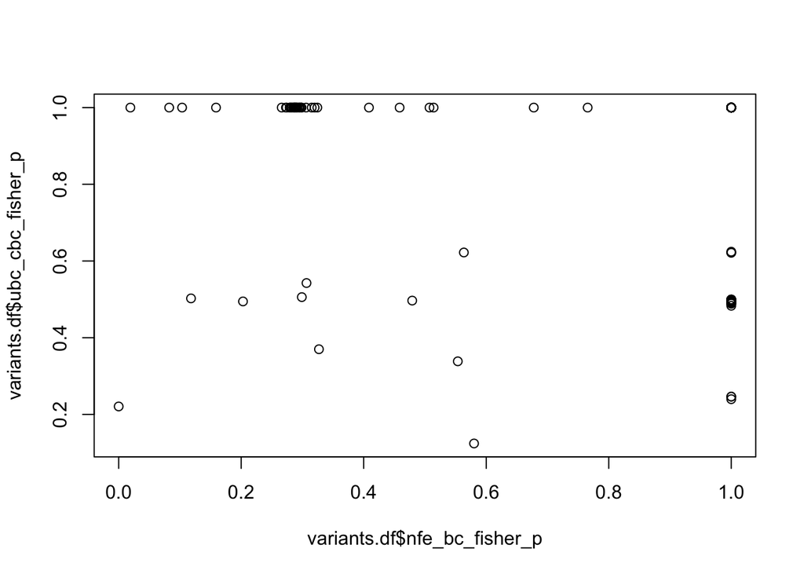

```r
# Plot different p-values against each other
plot(variants.df$nfe_bc_fisher_p, variants.df$ubc_cbc_fisher_p)
```

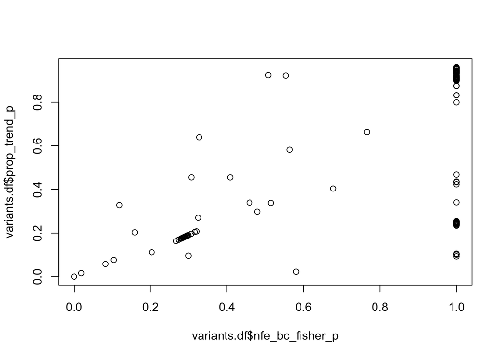

```r
plot(variants.df$nfe_bc_fisher_p, variants.df$prop_trend_p)
```

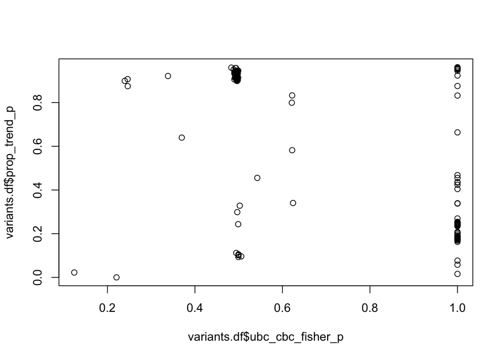

```r
plot(variants.df$ubc_cbc_fisher_p, variants.df$prop_trend_p)
```

# Crude “risk” candidates

```r
# Top "BC risk" candidates

variants.df %>%
  filter(crude_trend_direction=="Risk", nfe_bc_fisher_p < 0.05) %>%
  select(SplitVarID, SYMBOL, Consequence, CLIN_SIG,
         nfe_AF, ubc_AF, cbc_AF, nfe_bc_fisher_p, ubc_cbc_fisher_p,
         prop_trend_p, nfe_bc_fisher_fdr, ubc_cbc_fisher_fdr, prop_trend_fdr) %>%
  arrange(nfe_bc_fisher_p)
```

```
##  [1] SplitVarID         SYMBOL             Consequence        CLIN_SIG           nfe_AF             ubc_AF             cbc_AF             nfe_bc_fisher_p    ubc_cbc_fisher_p   prop_trend_p       nfe_bc_fisher_fdr  ubc_cbc_fisher_fdr prop_trend_fdr
## <0 rows> (or 0-length row.names)
```

```r
a <- variants.df %>% filter(crude_trend_direction=="Risk", nfe_bc_fisher_p < 0.05) %>% select(SplitVarID)

# Top "CBC risk" candidates
variants.df %>%
  filter(crude_trend_direction=="Risk", ubc_cbc_fisher_p < 0.05) %>%
  select(SplitVarID, SYMBOL, Consequence, CLIN_SIG,
         nfe_AF, ubc_AF, cbc_AF, nfe_bc_fisher_p, ubc_cbc_fisher_p,
         prop_trend_p, nfe_bc_fisher_fdr, ubc_cbc_fisher_fdr, prop_trend_fdr) %>%
  arrange(ubc_cbc_fisher_p)
```

```
##  [1] SplitVarID         SYMBOL             Consequence        CLIN_SIG           nfe_AF             ubc_AF             cbc_AF             nfe_bc_fisher_p    ubc_cbc_fisher_p   prop_trend_p       nfe_bc_fisher_fdr  ubc_cbc_fisher_fdr prop_trend_fdr
## <0 rows> (or 0-length row.names)
```

```r
b <- variants.df %>% filter(crude_trend_direction=="Risk", ubc_cbc_fisher_p < 0.05) %>% select(SplitVarID)

# Top "trend risk" candidates
variants.df %>%
  filter(crude_trend_direction=="Risk", prop_trend_p < 0.05) %>%
  select(SplitVarID, SYMBOL, Consequence, CLIN_SIG,
         nfe_AF, ubc_AF, cbc_AF, nfe_bc_fisher_p, ubc_cbc_fisher_p,
         prop_trend_p, nfe_bc_fisher_fdr, ubc_cbc_fisher_fdr, prop_trend_fdr) %>%
  arrange(prop_trend_p)
```

```
##     SplitVarID SYMBOL      Consequence CLIN_SIG nfe_AF ubc_AF      cbc_AF nfe_bc_fisher_p ubc_cbc_fisher_p prop_trend_p nfe_bc_fisher_fdr ubc_cbc_fisher_fdr prop_trend_fdr
## 1 Var000002734  NFXL1 missense_variant     <NA>      0      0 0.008658009       0.5801098        0.1242688   0.02223318                 1                  1      0.5145905
```

```r
c <- variants.df %>% filter(crude_trend_direction=="Risk", prop_trend_p < 0.05) %>% select(SplitVarID)

# Intersects

intersect(a,b)
```

```
## [1] SplitVarID
## <0 rows> (or 0-length row.names)
```

```r
intersect(b,c)
```

```
## [1] SplitVarID
## <0 rows> (or 0-length row.names)
```

```r
intersect(a,c)
```

```
## [1] SplitVarID
## <0 rows> (or 0-length row.names)
```

```r
# Clean-up
rm(a,b,c)
```

# Crude “protective” candidates

Anyway: it does not make sence to look at “protective” in low-frequency,  
because should not be rare, if beneficial …

```r
# Top "BC protective" candidates

variants.df %>%
  filter(crude_trend_direction=="Protective", nfe_bc_fisher_p < 0.05) %>%
  select(SplitVarID, SYMBOL, Consequence, CLIN_SIG,
         nfe_AF, ubc_AF, cbc_AF, nfe_bc_fisher_p, ubc_cbc_fisher_p,
         prop_trend_p, nfe_bc_fisher_fdr, ubc_cbc_fisher_fdr, prop_trend_fdr) %>%
  arrange(nfe_bc_fisher_p)
```

```
##     SplitVarID SYMBOL      Consequence CLIN_SIG      nfe_AF      ubc_AF     cbc_AF nfe_bc_fisher_p ubc_cbc_fisher_p prop_trend_p nfe_bc_fisher_fdr ubc_cbc_fisher_fdr prop_trend_fdr
## 1 Var000003110  DCHS2 missense_variant     <NA> 0.067934783 0.007075472 0.01674641    4.663522e-07        0.2207914 3.411647e-05      7.554905e-05                  1    0.005526868
## 2 Var000005670  GBGT1 missense_variant     <NA> 0.008823529 0.000000000 0.00000000    1.906385e-02        1.0000000 1.584317e-02      1.000000e+00                  1    0.514590516
```

```r
a <- variants.df %>% filter(crude_trend_direction=="Protective", nfe_bc_fisher_p < 0.05) %>% select(SplitVarID)

# Top "CBC protective" candidates
variants.df %>%
  filter(crude_trend_direction=="Protective", ubc_cbc_fisher_p < 0.05) %>%
  select(SplitVarID, SYMBOL, Consequence, CLIN_SIG,
         nfe_AF, ubc_AF, cbc_AF, nfe_bc_fisher_p, ubc_cbc_fisher_p,
         prop_trend_p, nfe_bc_fisher_fdr, ubc_cbc_fisher_fdr, prop_trend_fdr) %>%
  arrange(ubc_cbc_fisher_p)
```

```
##  [1] SplitVarID         SYMBOL             Consequence        CLIN_SIG           nfe_AF             ubc_AF             cbc_AF             nfe_bc_fisher_p    ubc_cbc_fisher_p   prop_trend_p       nfe_bc_fisher_fdr  ubc_cbc_fisher_fdr prop_trend_fdr
## <0 rows> (or 0-length row.names)
```

```r
b <- variants.df %>% filter(crude_trend_direction=="Protective", ubc_cbc_fisher_p < 0.05) %>% select(SplitVarID)

# Top "trend protective" candidates
variants.df %>%
  filter(crude_trend_direction=="Protective", prop_trend_p < 0.05) %>%
  select(SplitVarID, SYMBOL, Consequence, CLIN_SIG,
         nfe_AF, ubc_AF, cbc_AF, nfe_bc_fisher_p, ubc_cbc_fisher_p,
         prop_trend_p, nfe_bc_fisher_fdr, ubc_cbc_fisher_fdr, prop_trend_fdr) %>%
  arrange(prop_trend_p)
```

```
##     SplitVarID SYMBOL      Consequence CLIN_SIG      nfe_AF      ubc_AF     cbc_AF nfe_bc_fisher_p ubc_cbc_fisher_p prop_trend_p nfe_bc_fisher_fdr ubc_cbc_fisher_fdr prop_trend_fdr
## 1 Var000003110  DCHS2 missense_variant     <NA> 0.067934783 0.007075472 0.01674641    4.663522e-07        0.2207914 3.411647e-05      7.554905e-05                  1    0.005526868
## 2 Var000005670  GBGT1 missense_variant     <NA> 0.008823529 0.000000000 0.00000000    1.906385e-02        1.0000000 1.584317e-02      1.000000e+00                  1    0.514590516
```

```r
c <- variants.df %>% filter(crude_trend_direction=="Protective", prop_trend_p < 0.05) %>% select(SplitVarID)

# Intersects

intersect(a,b)
```

```
## [1] SplitVarID
## <0 rows> (or 0-length row.names)
```

```r
intersect(b,c)
```

```
## [1] SplitVarID
## <0 rows> (or 0-length row.names)
```

```r
intersect(a,c)
```

```
##     SplitVarID
## 1 Var000003110
## 2 Var000005670
```

```r
# Clean-up
rm(a,b,c)
```

# QQ-plots

Assuming uniform p-value distributions under the null-hypothesis

```r
# nfe_bc_fisher_p
min(variants.df$nfe_bc_fisher_p)
```

```
## [1] 4.663522e-07
```

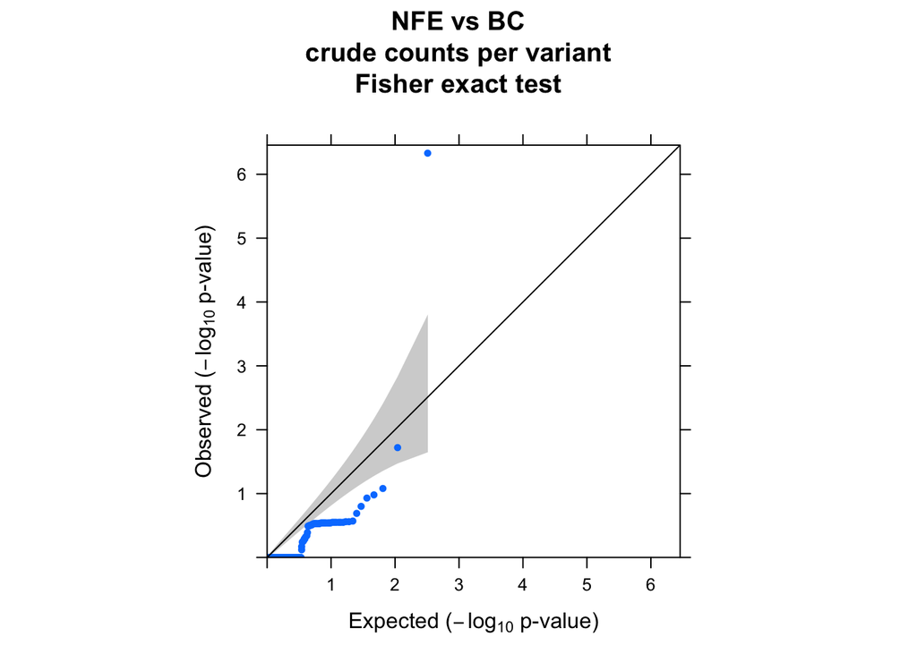

```r
p_obs <- variants.df$nfe_bc_fisher_p
p_exp <- ppoints(p_obs)
cptn="NFE vs BC\ncrude counts per variant\nFisher exact test"

qqunif.plot(p_obs, main=cptn)
```

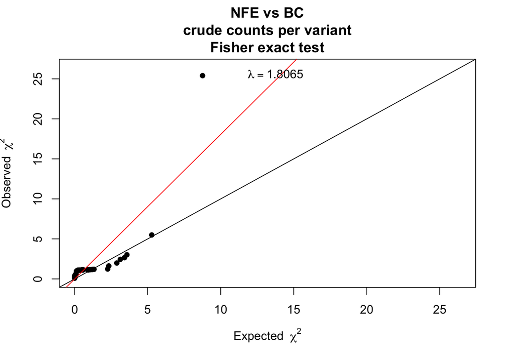

```
## $estimate
## [1] 1.806493
##
## $se
## [1] 0.1498776
```

```r
estlambda2(p.o=p_obs, p.e=p_exp, plot=T, main=cptn)
```

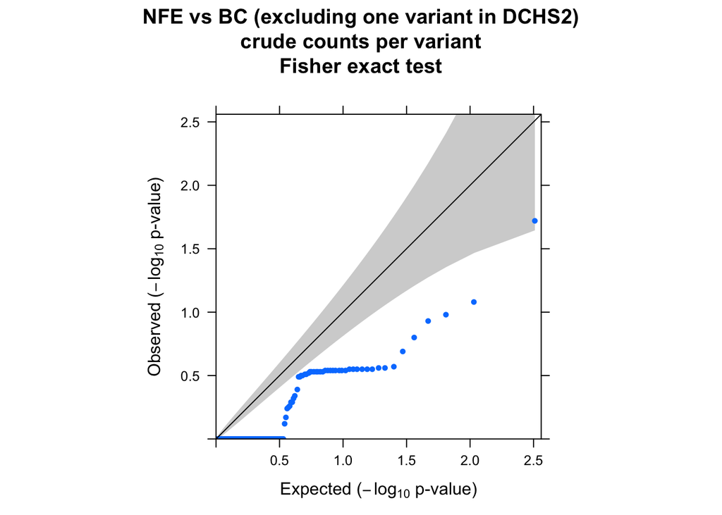

```r
p_obs <- variants.df[variants.df$SplitVarID!="Var000003110","nfe_bc_fisher_p"]
p_exp <- ppoints(p_obs)
cptn="NFE vs BC (excluding one variant in DCHS2)\ncrude counts per variant\nFisher exact test"

qqunif.plot(p_obs, main=cptn)
```

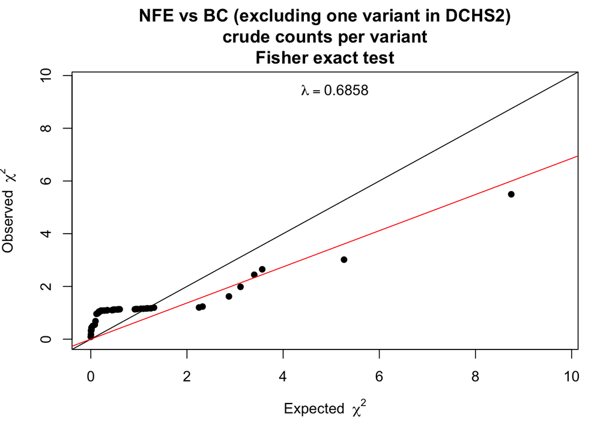

```
## $estimate
## [1] 0.6857908
##
## $se
## [1] 0.04871134
```

```r
estlambda2(p.o=p_obs, p.e=p_exp, plot=T, main=cptn)
```

```r
# ubc_cbc_fisher_p
min(variants.df$ubc_cbc_fisher_p)
```

```
## [1] 0.1242688
```

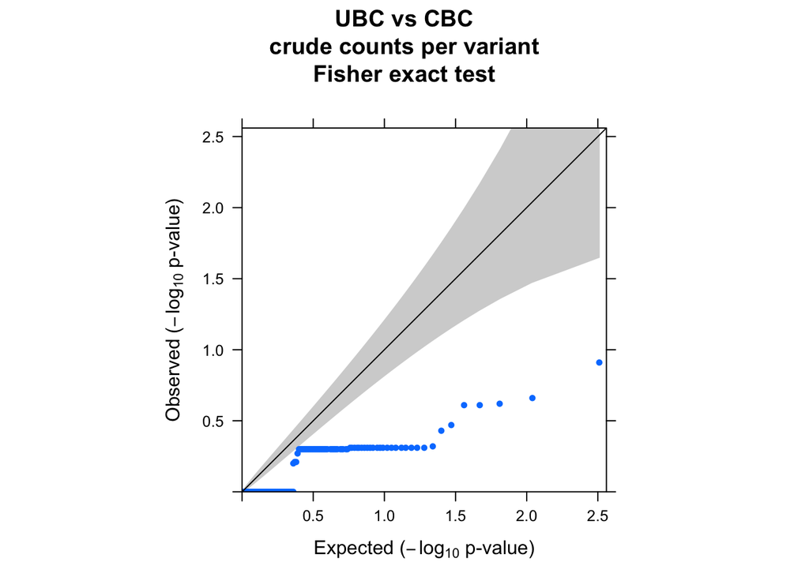

```r
p_obs <- variants.df$ubc_cbc_fisher_p
p_exp <- ppoints(p_obs)
cptn="UBC vs CBC\ncrude counts per variant\nFisher exact test"

qqunif.plot(p_obs, main=cptn)
```

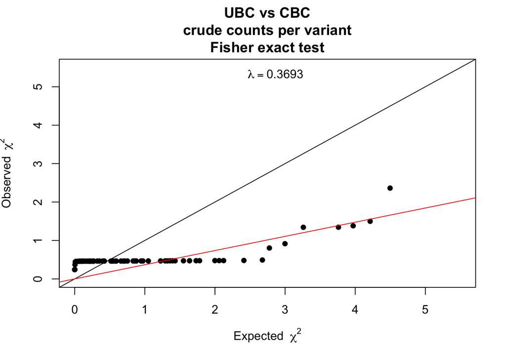

```
## $estimate
## [1] 0.3693363
##
## $se
## [1] 0.02581397
```

```r
estlambda2(p.o=p_obs, p.e=p_exp, plot=T, main=cptn)
```

```r
# prop trend p
min(variants.df$prop_trend_p)
```

```
## [1] 3.411647e-05
```

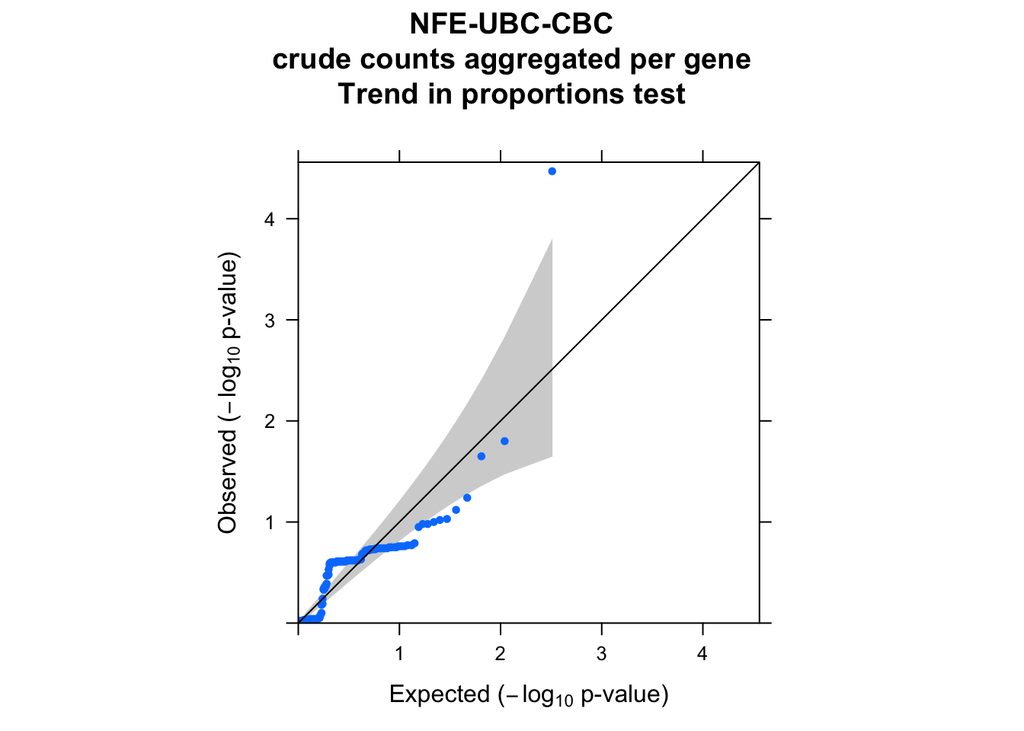

```r
p_obs <- variants.df$prop_trend_p
p_exp <- ppoints(p_obs)
cptn="NFE-UBC-CBC\ncrude counts aggregated per gene\nTrend in proportions test"

qqunif.plot(p_obs, main=cptn)
```

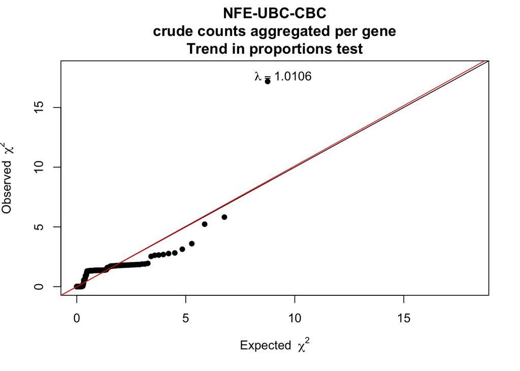

```
## $estimate
## [1] 1.010626
##
## $se
## [1] 0.03855711
```

```r
estlambda2(p.o=p_obs, p.e=p_exp, plot=T, main=cptn)
```

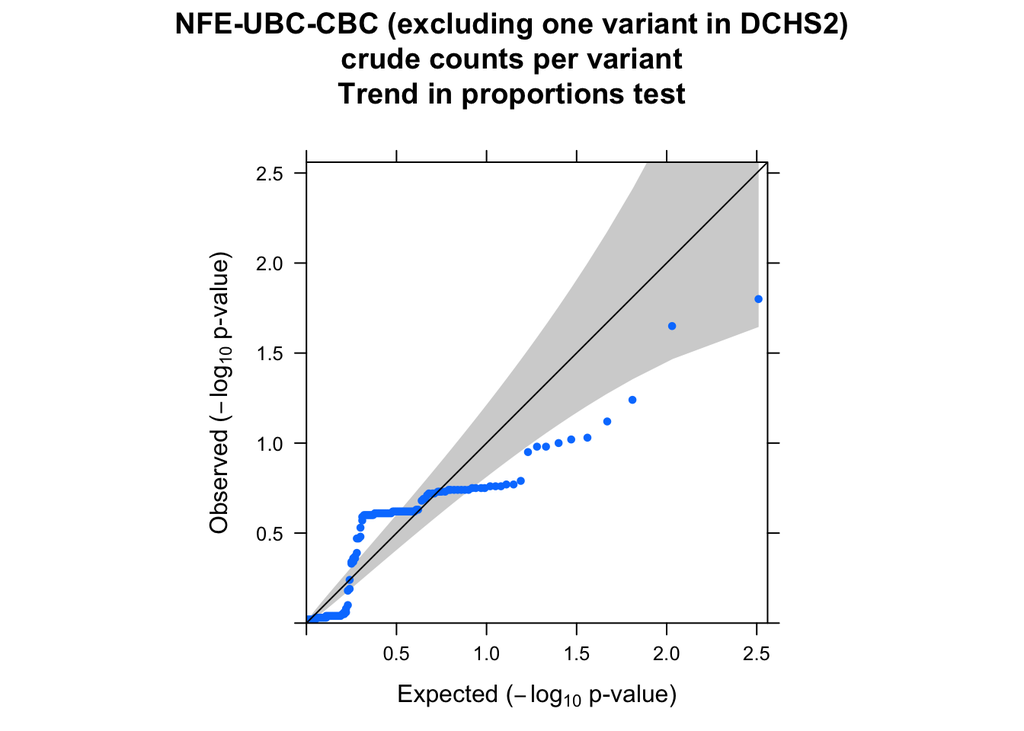

```r
p_obs <- variants.df[variants.df$SplitVarID!="Var000003110","prop_trend_p"]
p_exp <- ppoints(p_obs)
cptn="NFE-UBC-CBC (excluding one variant in DCHS2)\ncrude counts per variant\nTrend in proportions test"

qqunif.plot(p_obs, main=cptn)
```

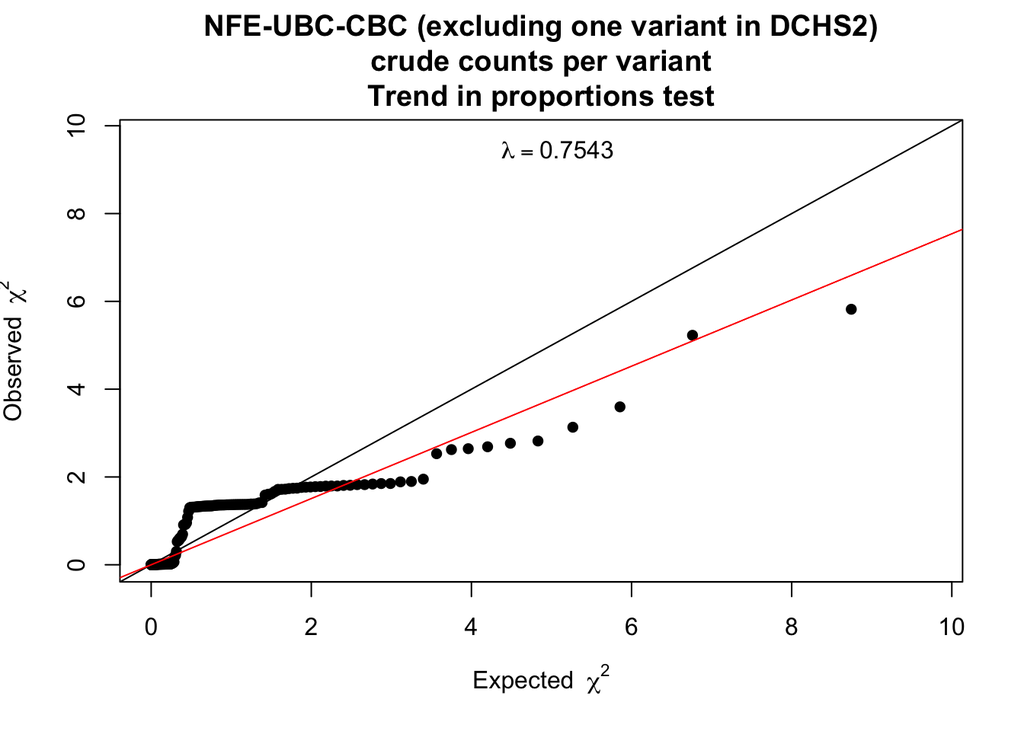

```
## $estimate
## [1] 0.7542523
##
## $se
## [1] 0.02090409
```

```r
estlambda2(p.o=p_obs, p.e=p_exp, plot=T, main=cptn)
```

```r
# Clean-up
rm(qqunif.plot, p_exp, p_obs, cptn)
```

# explore_MACs

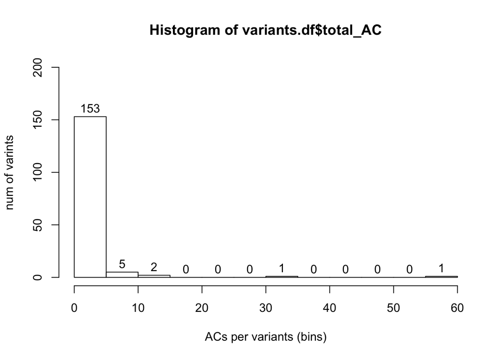

```r
# Histograms of MACs
hist(variants.df$total_AC, labels = TRUE, ylim=c(0,200),
     xlab="ACs per variants (bins)", ylab="num of varints")
```

```r
mean(variants.df$total_AC)
```

```
## [1] 2.222222
```

```r
median(variants.df$total_AC)
```

```
## [1] 1
```

```r
# Variants with high MACs (non-weighted!)
# All trends are driven by nfe vs ampliseq ...
variants.df %>%
  select(SplitVarID, total_AF, total_AC, SYMBOL, Consequence, CLIN_SIG,
         nfe_bc_fisher_p, ubc_cbc_fisher_p,prop_trend_p,crude_trend_direction) %>%
  filter(total_AC>10) %>%
  arrange(desc(total_AC))
```

```
##     SplitVarID    total_AF total_AC SYMBOL      Consequence CLIN_SIG nfe_bc_fisher_p ubc_cbc_fisher_p prop_trend_p crude_trend_direction
## 1 Var000004212 0.045878694       59 RNF133       start_lost     <NA>    5.536093e-01        0.3384391 9.216198e-01            Protective
## 2 Var000003110 0.028925620       35  DCHS2 missense_variant     <NA>    4.663522e-07        0.2207914 3.411647e-05            Protective
## 3 Var000002948 0.009789157       13  DCHS2 missense_variant     <NA>    7.655756e-01        1.0000000 6.634815e-01                  Risk
## 4 Var000013015 0.008675079       11 RNF128 missense_variant     <NA>    3.066024e-01        0.5425285 4.553258e-01                  Risk
```

# data_summary

```r
ls()
```

```
## [1] "base_folder"   "genotypes.mx"  "phenotypes.df" "variants.df"
```

```r
dim(genotypes.mx)
```

```
## [1] 162 664
```

```r
dim(variants.df)
```

```
## [1] 162  87
```

```r
dim(phenotypes.df)
```

```
## [1] 664  31
```

```r
# Check consistency of rownames and colnames
sum(colnames(genotypes.mx) != rownames(phenotypes.df))
```

```
## [1] 0
```

```r
sum(rownames(genotypes.mx) != rownames(variants.df))
```

```
## [1] 0
```

# save_data

```r
save.image(paste(base_folder, "s01_crude_variants_stats.RData", sep="/"))
```

# final_section

```r
ls()
```

```
## [1] "base_folder"   "genotypes.mx"  "phenotypes.df" "variants.df"
```

```r
Sys.time()
```

```
## [1] "2019-09-19 18:07:35 BST"
```